# **Traffic Sign Classifier**

## Overview

Develop a Deep Leaning Network to classify traffic signs. To accomplish this a Convolutional Neural Network (CNN) will be developed to classify traffic signs. Specifically the CNN will focus on German traffic signs. [German Traffic Sign Dataset](http://benchmark.ini.rub.de/?section=gtsrb&subsection=dataset).

## Requirements

The requirements are:

- Architecure based on LeNet-5 implementation.
- Outline any preprocessing techniques used (normalization, rgb to grayscale, etc)
- Outline any balancing techniques used on the number of examples per label (some have more than others).
- Evaluate if the Neural Network is over or underfitting?)
- Generate fake data
- The Neural Network needs to have a validation set accuracy >= 0.93

## Steps

The steps involved are:

- Get the Test Data and Display Attributes
- Plot the Test Data
- Plot Histogram of Test Data
- Pre-process the data set
  - Balance the training set
  - Plot the histogram of the balanced training set
  - Equalize the data set
  - Normalize the data set
- TrafficSignNet Architecture
- Train, Validate and Test the Model
- Features and Labels
- Training Pipeline
- Model Evaluation
- Train the Model
- Evaluate the Model
- Test on random images
- Predict the Sign Type for Each Image
- Output Top 5 Softmax Probabilities for each image found on the web

## Import Packages

```python
import tensorflow as tf
import matplotlib.image as mpimg
import matplotlib.pyplot as plt
from sklearn.utils import shuffle
import numpy as np
import cv2
import os
import math
import pickle
import csv
import random
%matplotlib inline
```

## Traffic Sign Classifier Helper Functions

Below are the helper functions for Traffic Sign Classification!

```python
# Create a Class for some useful Enums
class Enum( tuple ): __getattr__ = tuple.index

# Define Enum for handling Data Sets
DataSet = Enum( ['TRAIN', 'VALID', 'TEST', 'RANDOM'] )

# Define Enum for different equalization modes
EqualizeMode = Enum( ['NORMAL', 'ADAPTIVE'] )

def get_test_data( test_data_dir ):
   """Get Test Data"""
   for filename in os.listdir( test_data_dir ):
       if any( filename.endswith( f ) for f in ( '.p' ) ):
           if filename == 'train.p':
               with open(test_data_dir+'/'+filename, mode='rb') as f:
                   train = pickle.load(f)
           elif filename == 'valid.p':
               with open(test_data_dir+'/'+filename, mode='rb') as f:
                   valid = pickle.load(f)
           elif filename == 'test.p':
               with open(test_data_dir+'/'+filename, mode='rb') as f:
                   test = pickle.load(f)
           else:
               print(" unknown filename {}".format( filename ) )
   return train, valid,test

def get_sign_names( test_data_dir ):
   """Extract sign names from CSV file"""
   with open('signnames.csv', mode='r') as f:
       reader = csv.reader(f)
       next( reader )
       signs = list( reader )
   return signs

def plot_dataset_images( dataset ):
   """Plot images in a neat fashion using subplot"""
   plot_cols = 4
   plot_rows = math.ceil( n_classes / plot_cols )
   plt.figure( figsize = ( 15, 40 ), facecolor='white' )
   for i in range( n_classes ):
       plot_num = i+1
       ax = plt.subplot( plot_rows, plot_cols, plot_num )
       if dataset == DataSet.TRAIN:
           img = X_train[y_train == i]
       elif dataset == DataSet.VALID:
           img = X_valid[y_valid == i]
       elif dataset == DataSet.TEST:
           img = X_test[y_test == i]
       else:
           print(" unknown dataset")
       plt.imshow( img[0, :, :, :] )
       ax.set_title( signs[i][1], fontsize = 12 )
   plt.tight_layout()

def plot_histogram( data, dataset ):
   """Plot histogram to show distribution of test_data"""
   plt.figure( figsize = ( 20, 10 ), facecolor='white' )
   if dataset == DataSet.TRAIN:
       plt.title( 'Histogram of X_train across all Class Ids', fontsize = 24 )
   elif dataset == DataSet.VALID:
       plt.title( 'Histogram of X_valid across all Class Ids', fontsize = 24 )
   elif dataset == DataSet.TEST:
       plt.title( 'Histogram of X_test across all Class Ids', fontsize = 24 )
   else:
       print(" unknown plottype")
   plt.ylabel( 'Num Images per Class Id', fontsize = 16 )
   plt.xlabel( 'Class Id', fontsize = 16 )
   plt.hist( data, len( signs ) )

def equalize_data( img, mode ):
   """Applies Histogram Equalization to enhance contrast"""
   img = img.copy()
   if mode == EqualizeMode.ADAPTIVE:
       lab = cv2.cvtColor( img, cv2.COLOR_BGR2LAB )
       lab_planes = cv2.split( lab )
       clahe = cv2.createCLAHE( clipLimit=2.0,tileGridSize=( 4,4 ) )
       lab_planes[0] = clahe.apply( lab_planes[0] )
       lab = cv2.merge( lab_planes )
       img = cv2.cvtColor( lab, cv2.COLOR_LAB2BGR )
   elif mode == EqualizeMode.NORMAL:
       for channel in range( 3 ):
           img[:,:,channel] = cv2.equalizeHist( img[:,:,channel] )
   else:
       print(" unknown mode")
   return img

def normalize_data( img ):
   """Normalize to have zero mean"""
   img = img.copy()
   return ( img - 128. ) / 128.

def find_images( img_dir ):
   """Find and return a list of various image file formats"""
   image_files = []
   for filename in os.listdir( img_dir ):
       if any( filename.endswith( f ) for f in ( '.jpg', '.jpeg','.gif', '.png' ) ):
           image_files.append( os.path.abspath( img_dir+'/'+filename ) )
   return sorted( image_files )

def rotate_image( img, angle ):
   """Rotates an image using angle parameter"""
   img = img.copy()
   img_mid = tuple( np.array( img.shape[0:2] ) / 2 )
   rot_mat = cv2.getRotationMatrix2D( img_mid, angle, 1.0 )
   return cv2.warpAffine( img, rot_mat, img.shape[0:2], flags=cv2.INTER_LINEAR )

def balance_training_set( x, y, delta ):
   """Add images to classs Ids with below average representation"""
   # Add rotated images to x_extra until number of images equals the mean
   # The angle of rotation is randomly chosen from the range -25 to 25 degrees
   angles = list( range( -25,25 ) )
   for c in range( n_classes ):
       if delta[ c ] > 0:
           img = x[y==c]
           x_extra = [ rotate_image( img[c,:,:,:], random.choice( angles ) ) for i in range( delta[c] ) ]
           x = np.append( x, x_extra, axis=0 )
           y = np.append( y, np.full( ( x.shape[0] - y.shape[0] ), c, dtype = int ) )
   return x,y
```

## Get the Test Data and Show Attributes

The test_data is a set of pickle files in dictionary format with 4 key/value pairs:

- `features` A 4D array of raw pixel data of the traffic sign images, (num examples, width, height, channels).
- `labels` A 1D array containing the label/class id of the traffic sign. The file `signnames.csv` contains id -> name mappings for each id.
- `sizes` A list of tuples, (width, height) representing the original width and height the image.
- `coords` A list of tuples, (x1, y1, x2, y2) representing coordinates of a bounding box around the sign in the image.

```python
# Get the Test Data
train, valid, test = get_test_data( 'test_data' )

# Extract the features and labels from the test data
X_train = train['features']
y_train = train['labels']

X_valid = valid['features']
y_valid = valid['labels']

X_test  = test['features']
y_test  = test['labels']

# Display Test Data Summary
n_train = X_train.shape[0]
n_valid = X_valid.shape[0]
n_test = X_test.shape[0]

image_shape = X_train[0].shape
n_classes = len( set( y_train ) )

print( "Number of training examples =", n_train )
print( "Number of validation examples =", n_valid )
print( "Number of testing examples =", n_test )
print( "Image data shape =", image_shape )
print( "Number of classes =", n_classes )

# Get Sign Names
signs = get_sign_names( 'test_data' )
```

```
Number of training examples = 34799
Number of validation examples = 4410
Number of testing examples = 12630
Image data shape = (32, 32, 3)
Number of classes = 43
```

## Plot Training Images

Sample only - Plot the first image from each ClassId

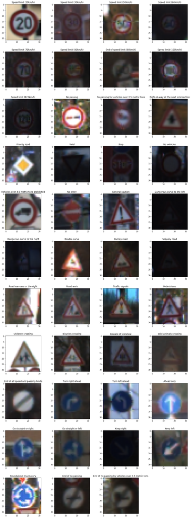

```python
plot_dataset_images( DataSet.TRAIN )
```

## Plot Histogram of Training Images

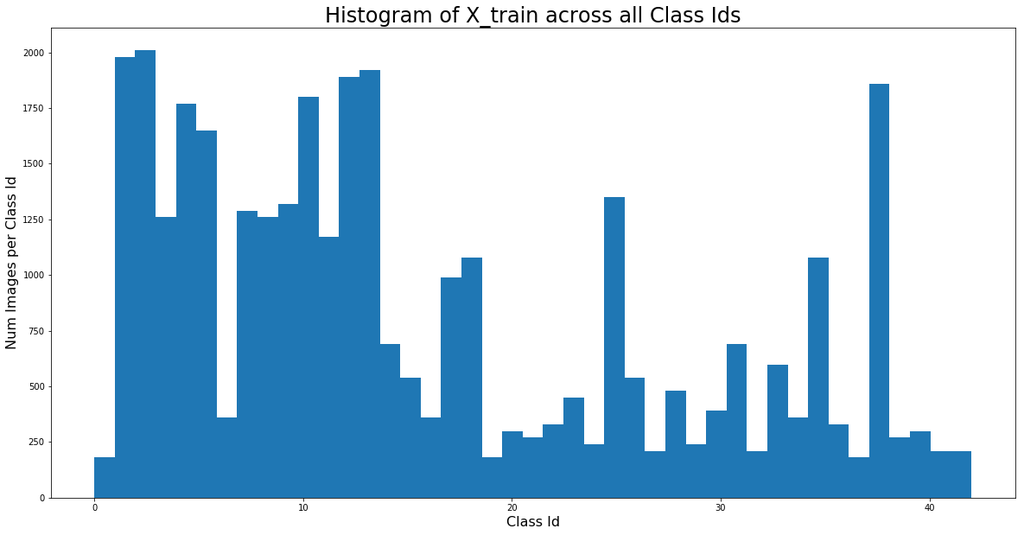

```python
plot_histogram( y_train, DataSet.TRAIN )
```

## Plot Validation Images

Sample only - Plot the first image from each ClassId

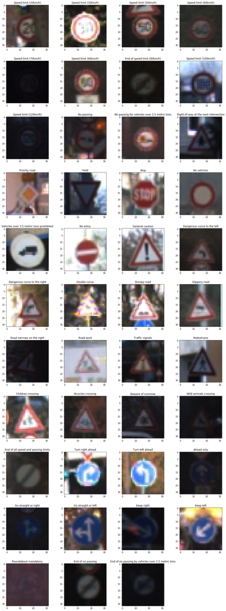

```python
plot_dataset_images( DataSet.VALID )
```

## Plot Histogram of Validation Images

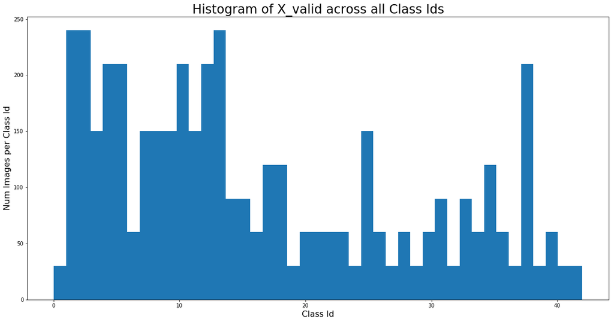

```python
plot_histogram( y_valid, DataSet.VALID )
```

## Plot Test Images

Sample only - Plot the first image from each ClassId

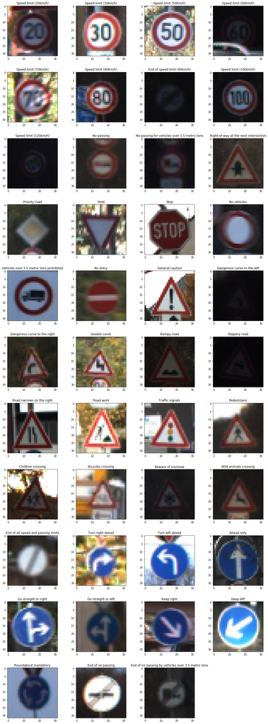

```python
plot_dataset_images( DataSet.TEST )
```

## Plot Histogram of Test Images

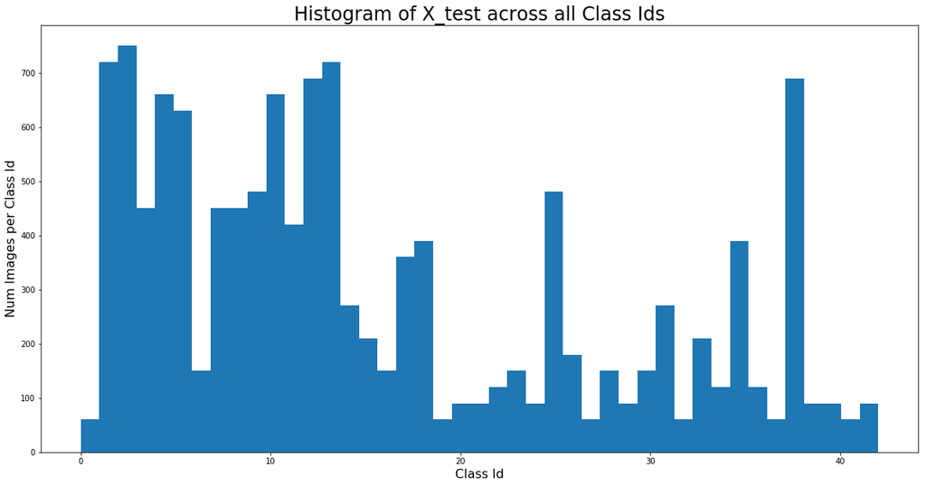

```python
plot_histogram( y_test, DataSet.TEST )
```

## Pre-process ( Stage 1 )

- Balance the training set as follows:
  - Determine the mean across all class id
  - Determine the delta_to_mean for each under represented class
  - For each class, read an image and add randomly rotated versions of the image until the number of images in the class reaches the mean
  - The balanced training dataset increases from 34799 to 46740

```
classid_mean = 810 classid_min = 180 classid_max = 2010
classid_hist= [ 180 1980 2010 1260 1770 1650  360 1290 1260 1320 1800 1170 1890 1920  690
  540  360  990 1080  180  300  270  330  450  240 1350  540  210  480  240
  390  690  210  599  360 1080  330  180 1860  270  300  210  210]
delta_to_mean=[630, 0, 0, 0, 0, 0, 450, 0, 0, 0, 0, 0, 0, 0, 120, 270, 450, 0, 0, 630, 510, 540, 480, 360, 570, 0, 270, 600, 330, 570, 420, 120, 600, 211, 450, 0, 480, 630, 0, 540, 510, 600, 600]
Number of training examples = 34799
Number of training examples (balanced) = 46740
Plot new histogram
```

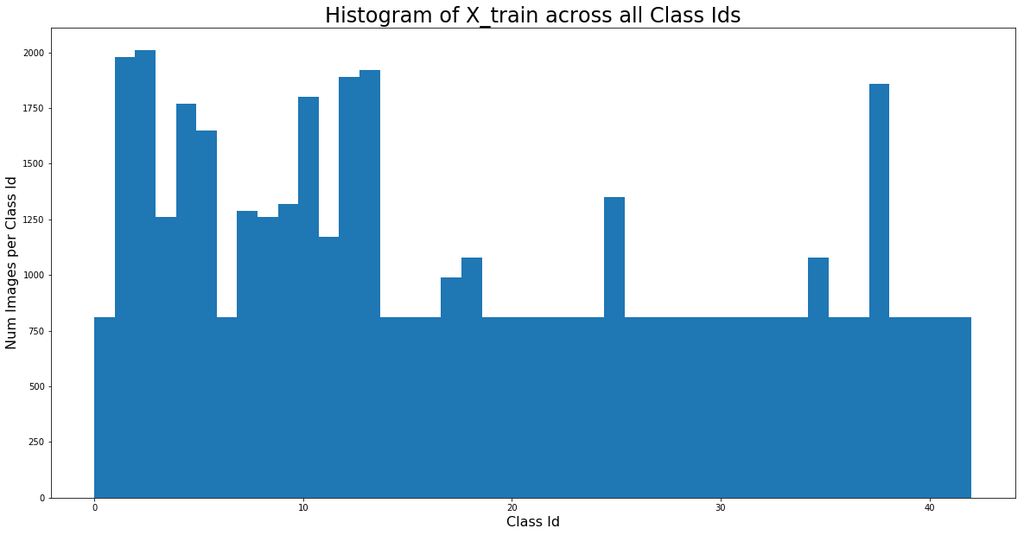

```python
inputs_per_class = np.bincount( y_train )
classid_max = np.max( inputs_per_class )
classid_min = np.min( inputs_per_class )
classid_mean = math.ceil( np.mean( inputs_per_class ) )
classid_hist, _ = np.histogram( y_train, bins = n_classes )

print("classid_mean = {} classid_min = {} classid_max = {}".format( classid_mean, classid_min, classid_max ) )

print("classid_hist=",classid_hist )

# Calculate the delta to mean for under represented images
delta_to_mean = [ classid_mean-i if i<classid_mean else 0 for i in classid_hist ]

print("delta_to_mean={} ".format( delta_to_mean ) )

print("Number of training examples =", X_train.shape[0] )

X_train, y_train = balance_training_set( X_train, y_train, delta_to_mean )
print("Number of training examples (balanced) =", X_train.shape[0] )

print("Plot new histogram")
plot_histogram( y_train, DataSet.TRAIN )
```

## Pre-process ( Stage 2 )

- Apply Histogram Equalization to the data set (Normal or CLAHE) to enhance the contrast of the training set
- Finally Normalize the data for zero mean and equal variance using `(pixel - 128)/ 128`

```python
print("Equalize each data set")
equalize_mode = EqualizeMode.ADAPTIVE
X_train = np.array( [ equalize_data( img, equalize_mode ) for img in X_train] )
X_valid = np.array( [ equalize_data( img, equalize_mode ) for img in X_valid] )
X_test  = np.array( [ equalize_data( img, equalize_mode ) for img in X_test] )

print("Normalize each data set")
X_train = np.array( [ normalize_data( img ) for img in X_train] )
X_valid = np.array( [ normalize_data( img ) for img in X_valid] )
X_test  = np.array( [ normalize_data( img ) for img in X_test] )

print("Calculate and print the Mean of each data set. Mean should be close to 0 ")
print("X_train mean (normalized) = {}".format( np.mean( X_train ) ) )
print("X_valid mean (normalized) = {}".format( np.mean( X_valid ) ) )
print("X_test  mean (normalized) = {}".format( np.mean( X_test ) ) )
```

```
Equalize each data set
Normalize each data set
Calculate and print the Mean of each data set. Mean should be close to 0
X_train mean (normalized) = 0.20847013525472458
X_valid mean (normalized) = 0.23152717596098768
X_test  mean (normalized) = 0.24098051065629691
```

## Plot Normalized and Equalized Training Images

Sample only - Plot the first image from each ClassId

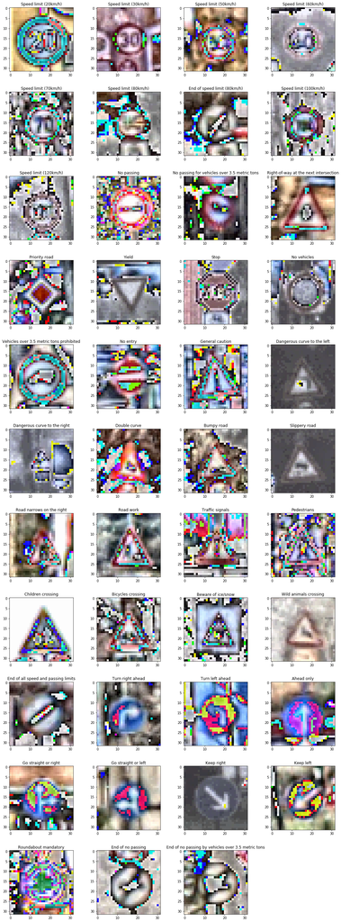

```python
plot_dataset_images( DataSet.TRAIN )
```

## TrafficSignNet Architecture

This architecture takes LeNet as the base design and adds a Dropout after each Regularization layer. Dropout was pioneered by Geoffrey Hinton and is known to work very well in reducing overfitting. I have run many training sesseions with Dropout and it definitely helps ( Consistenly get >=93% ).

- Layer 1:
  - Input = 32x32x3. Output = 28x28x6.
  - conv1_W:
    - Uses a 5x5 filter with input depth=3 and output depth=6.
    - The output_height = (input_height - filter_height)+1/vertical_stride, i.e 32-5+1/1 = 28.
    - The output_width = (input_width - filter_width)+1/horinzatal_stride, i.e. 32-5+1/1 = 28
  - conv1_b:
    - Bias vector, length = output_depth
  - conv1:
    - Convolve the filter over the images and add bias
    - Activate the output of conv1 with a RELU activation function
    - Pool the output with a 2x2 kernel with a 2x2 stride which gives us a pooling output of 14x14x6
    - Add a dropout layer with keep_prob < 1
- Layer 2:
  - Input = 14x14x6. Output = 5x5x16.
  - The steps from Layer 1 are repeated to create another layer
- Layer 3:
  - Fully Connected Layer.
  - Input = 400. Output = 120.
- Layer 4:
  - Fully Connected Layer.
  - Input = 120. Output = 84.
- Layer 5:
  - Fully Connected Layer.
  - Input = 84. Output = 43 which is number of classes in dataset.

```python
from tensorflow.contrib.layers import flatten

def TrafficSignNet( x ):
   mu = 0
   sigma = 0.1

   # Layer 1:
   conv1_W = tf.Variable( tf.truncated_normal( shape=(5, 5, 3, 6), mean = mu, stddev = sigma ) )
   conv1_b = tf.Variable( tf.zeros(6) )
   conv1   = tf.nn.conv2d( x, conv1_W, strides=[1, 1, 1, 1], padding='VALID' ) + conv1_b
   conv1   = tf.nn.relu(conv1)
   conv1   = tf.nn.max_pool( conv1, ksize=[1, 2, 2, 1], strides=[1, 2, 2, 1], padding='VALID' )
   conv1   = tf.nn.dropout( conv1, keep_prob )

   # Layer 2:
   conv2_W = tf.Variable( tf.truncated_normal( shape=(5, 5, 6, 16), mean = mu, stddev = sigma ) )
   conv2_b = tf.Variable( tf.zeros( 16 ) )
   conv2   = tf.nn.conv2d( conv1, conv2_W, strides=[1, 1, 1, 1], padding='VALID' ) + conv2_b
   conv2   = tf.nn.relu( conv2 )
   conv2   = tf.nn.max_pool( conv2, ksize=[1, 2, 2, 1], strides=[1, 2, 2, 1], padding='VALID' )
   conv2   = tf.nn.dropout( conv2, keep_prob )

   # Flatten the output to create a single vector. Input = 5x5x16. Output = 400.
   fc0   = flatten( conv2 )

   # Layer 3:
   fc1_W = tf.Variable( tf.truncated_normal( shape=(400, 120), mean = mu, stddev = sigma ) )
   fc1_b = tf.Variable( tf.zeros( 120 ) )
   fc1   = tf.matmul( fc0, fc1_W ) + fc1_b
   fc1   = tf.nn.relu( fc1 )
   fc1   = tf.nn.dropout( fc1, keep_prob )

   # Layer 4:
   fc2_W  = tf.Variable( tf.truncated_normal( shape=(120, 84), mean = mu, stddev = sigma ) )
   fc2_b  = tf.Variable( tf.zeros(84) )
   fc2    = tf.matmul( fc1, fc2_W ) + fc2_b
   fc2    = tf.nn.relu( fc2 )
   fc2   = tf.nn.dropout( fc2, keep_prob )

   # Layer 5:
   fc3_W  = tf.Variable( tf.truncated_normal( shape=(84, 43), mean = mu, stddev = sigma ) )
   fc3_b  = tf.Variable( tf.zeros( 43 ) )
   logits = tf.matmul( fc2, fc3_W ) + fc3_b

   return logits
```

## Train, Validate and Test the Model

A validation set can be used to assess how well the model is performing. A low accuracy on the training and validation sets imply underfitting. A high accuracy on the training set but low accuracy on the validation set implies overfitting.

## Features and Labels

`x` is a placeholder for a batch of input images. `y` is a placeholder for a batch of output labels.

```python
x = tf.placeholder( tf.float32,( None, 32, 32, 3 ) )
y = tf.placeholder( tf.int32,( None ) )
one_hot_y = tf.one_hot( y, n_classes )
keep_prob = tf.placeholder( tf.float32 )
```

## Training Pipeline

```python
EPOCHS = 50
BATCH_SIZE = 128
rate = 0.001

logits = TrafficSignNet( x )
cross_entropy = tf.nn.softmax_cross_entropy_with_logits( labels=one_hot_y, logits=logits )
loss_operation = tf.reduce_mean( cross_entropy )
optimizer = tf.train.AdamOptimizer( learning_rate = rate )
training_operation = optimizer.minimize( loss_operation )
```

## Model Evaluation

```python
correct_prediction = tf.equal( tf.argmax( logits, 1 ), tf.argmax( one_hot_y, 1 ) )
accuracy_operation = tf.reduce_mean( tf.cast(correct_prediction, tf.float32 ) )
saver = tf.train.Saver()

def evaluate( X_data, y_data ):
    num_examples = len( X_data )
    total_accuracy = 0
    session = tf.get_default_session()
    for offset in range( 0, num_examples, BATCH_SIZE ):
        batch_x, batch_y = X_data[ offset:offset+BATCH_SIZE ], y_data[ offset:offset+BATCH_SIZE ]
        accuracy = session.run( accuracy_operation, feed_dict={ x: batch_x, y: batch_y, keep_prob: 1.0 } )
        total_accuracy += ( accuracy * len( batch_x ) )
    return total_accuracy / num_examples
```

## Train the Model

```python
with tf.Session() as session:
    session.run( tf.global_variables_initializer() )
    num_examples = len( X_train )

    print("Training...")
    print()
    for i in range( EPOCHS ):
        X_train, y_train = shuffle( X_train, y_train )
        for offset in range( 0, num_examples, BATCH_SIZE ):
            end = offset + BATCH_SIZE
            batch_x, batch_y = X_train[ offset:end ], y_train[ offset:end ]
            session.run( training_operation, feed_dict={ x: batch_x, y: batch_y, keep_prob: 0.80 } )

        validation_accuracy = evaluate( X_valid, y_valid )
        print("EPOCH {} ...".format( i+1 ) )
        print("Validation Accuracy = {:.3f}".format(validation_accuracy ) )
        print()

    saver.save( session, './traffic_sign_net' )
    print("Model saved")
```

```
Training...

EPOCH 1 ...
Validation Accuracy = 0.755

EPOCH 2 ...
Validation Accuracy = 0.861

EPOCH 3 ...
Validation Accuracy = 0.906

EPOCH 4 ...
Validation Accuracy = 0.917

EPOCH 5 ...
Validation Accuracy = 0.930

EPOCH 6 ...
Validation Accuracy = 0.936

EPOCH 7 ...
Validation Accuracy = 0.937

EPOCH 8 ...
Validation Accuracy = 0.943

EPOCH 9 ...
Validation Accuracy = 0.941

EPOCH 10 ...
Validation Accuracy = 0.943

EPOCH 11 ...
Validation Accuracy = 0.950

EPOCH 12 ...
Validation Accuracy = 0.948

EPOCH 13 ...
Validation Accuracy = 0.954
```

[output cut: 98 more lines]

```
Validation Accuracy = 0.960

EPOCH 47 ...
Validation Accuracy = 0.964

EPOCH 48 ...
Validation Accuracy = 0.961

EPOCH 49 ...
Validation Accuracy = 0.965

EPOCH 50 ...
Validation Accuracy = 0.965

Model saved
```

## Evaluate the Model

Do this once!

```python
with tf.Session() as session:
    saver.restore(session, tf.train.latest_checkpoint('.'))

    training_set_accuracy = evaluate(X_train, y_train)
    print( "Training Set Accuracy = {:.3f}".format( training_set_accuracy ) )

    validation_set_accuracy = evaluate(X_valid, y_valid )
    print( "Validation Set Accuracy = {:.3f}".format( validation_set_accuracy ) )

    test_set_accuracy = evaluate(X_test, y_test)
    print( "Test Set Accuracy = {:.3f}".format( test_set_accuracy ) )
```

```
Training Set Accuracy = 0.999
Validation Set Accuracy = 0.965
Test Set Accuracy = 0.961
```

## Test on random images

```
Get Random Test Set
Resize random images to 32x32
X_random.shape =  (6, 32, 32, 3)
Equalize the data set
Normalize each data set
Print the Mean of random data set. Mean should be close to 0
X_random mean = 0.4881943596733941
```

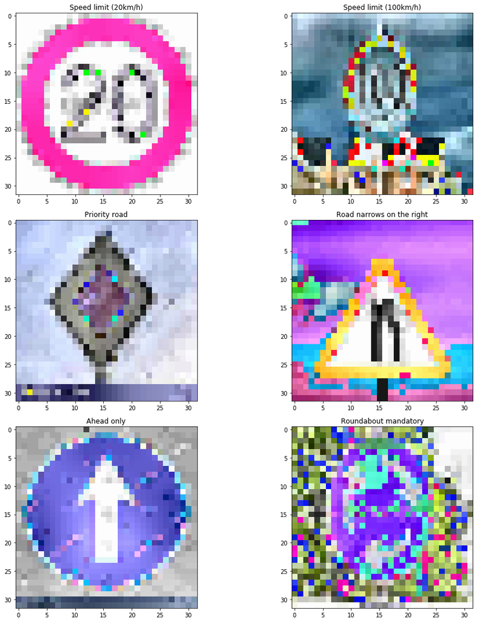

```python
print( "Get Random Test Set")
random_images = find_images( 'random_traffic_signs' )

print("Resize random images to 32x32")
X_random = np.array( [ cv2.resize(plt.imread( img ), (32, 32) ) for img in random_images ] )
print( "X_random.shape = ", X_random.shape )

print("Equalize the data set")
X_random = np.array( [ equalize_data( img, equalize_mode ) for img in X_random] )

print("Normalize each data set")
X_random = np.array( [ normalize_data( img ) for img in X_random] )

print("Print the Mean of random data set. Mean should be close to 0 ")
print("X_random mean = {}".format( np.mean( X_random ) ) )

actual_label = [ 0,7,12,24,35,40 ]

plt.figure( figsize = ( 15, 15 ), facecolor='white' )
plot_cols = 2
plot_rows = math.ceil( len(random_images) / plot_cols )
for i in range( len(random_images) ):
   plot_num = i+1
   ax = plt.subplot( plot_rows, plot_cols, plot_num )
   plt.imshow(X_random[i, :, :, :])
   ax.set_title( signs[actual_label[i]][1], fontsize = 12 )
plt.tight_layout()
```

## Predict the Sign Type for Each Image

```python
prediction = tf.argmax( logits, 1 )

with tf.Session() as session:
   saver.restore( session, tf.train.latest_checkpoint('.') )
   predictions = session.run( prediction, feed_dict={ x: X_random, keep_prob: 1.0 } )

for i, p in enumerate( predictions ):
   print("prediction label = {:2d}, actual label = {:2d}".format(p, actual_label[i] ) )
```

```
prediction label =  0, actual label =  0
prediction label = 25, actual label =  7
prediction label = 12, actual label = 12
prediction label = 24, actual label = 24
prediction label = 35, actual label = 35
prediction label = 40, actual label = 40
```

## Output Top 5 Softmax Probabilities For Each Image Found on the Web

```python
softmax_logits = tf.nn.softmax( logits )
top5 = tf.nn.top_k( softmax_logits, k=5 )
with tf.Session() as session:
    saver.restore( session, tf.train.latest_checkpoint('.') )
    softmax_data = session.run( softmax_logits, feed_dict={ x: X_random, keep_prob: 1.0 } )
    top5_softmax = session.run( top5, feed_dict={ x: X_random, keep_prob: 1.0 } )

for i in range( len(random_images) ):
    print( "Image: {}, Softmax Probability 1: {:.4f}".format( signs[ actual_label[i]][1], top5_softmax[0][i][0] ) )
    print( "Image: {}, Softmax Probability 2: {:.4f}".format( signs[ actual_label[i]][1], top5_softmax[0][i][1] ) )
    print( "Image: {}, Softmax Probability 3: {:.4f}".format( signs[ actual_label[i]][1], top5_softmax[0][i][2] ) )
    print( "Image: {}, Softmax Probability 4: {:.4f}".format( signs[ actual_label[i]][1], top5_softmax[0][i][3] ) )
    print( "Image: {}, Softmax Probability 5: {:.4f}".format( signs[ actual_label[i]][1], top5_softmax[0][i][4] ) )
    print(" ")
```

```
Image: Speed limit (20km/h), Softmax Probability 1: 0.7086
Image: Speed limit (20km/h), Softmax Probability 2: 0.2724
Image: Speed limit (20km/h), Softmax Probability 3: 0.0097
Image: Speed limit (20km/h), Softmax Probability 4: 0.0080
Image: Speed limit (20km/h), Softmax Probability 5: 0.0007

Image: Speed limit (100km/h), Softmax Probability 1: 0.9518
Image: Speed limit (100km/h), Softmax Probability 2: 0.0153
Image: Speed limit (100km/h), Softmax Probability 3: 0.0088
Image: Speed limit (100km/h), Softmax Probability 4: 0.0066
Image: Speed limit (100km/h), Softmax Probability 5: 0.0053

Image: Priority road, Softmax Probability 1: 1.0000
Image: Priority road, Softmax Probability 2: 0.0000
Image: Priority road, Softmax Probability 3: 0.0000
Image: Priority road, Softmax Probability 4: 0.0000
Image: Priority road, Softmax Probability 5: 0.0000

Image: Road narrows on the right, Softmax Probability 1: 0.7105
Image: Road narrows on the right, Softmax Probability 2: 0.2279
Image: Road narrows on the right, Softmax Probability 3: 0.0243
Image: Road narrows on the right, Softmax Probability 4: 0.0164
Image: Road narrows on the right, Softmax Probability 5: 0.0152

Image: Ahead only, Softmax Probability 1: 1.0000
Image: Ahead only, Softmax Probability 2: 0.0000
Image: Ahead only, Softmax Probability 3: 0.0000
Image: Ahead only, Softmax Probability 4: 0.0000
Image: Ahead only, Softmax Probability 5: 0.0000

Image: Roundabout mandatory, Softmax Probability 1: 0.9865
Image: Roundabout mandatory, Softmax Probability 2: 0.0123
Image: Roundabout mandatory, Softmax Probability 3: 0.0006
Image: Roundabout mandatory, Softmax Probability 4: 0.0003
Image: Roundabout mandatory, Softmax Probability 5: 0.0001
```